# Mental Models: Randomness

Bernard Ade

01-23-2017

The concept of **randomness** is vital to statistics. Randomness often takes on different meanings, there is the colloquial sense and when we refer to probability distributions. This post will address randomness as it relates to probability distributions, especially when we are examining outcomes and its probability density.

When we examine data we must observe its **true score** and **error**. We often make wrong estimates of what actually plays out in reality due to error or uncertainties which is why **randomness** is worthwhile of understanding.

We can understand randomness by studying shapes. The more random the shape the less likely we can make predictions or draw inference about the data. Some shapes reveals noise that varies from a little to a lot. For instance the most familiar random shape is called the **random walk**. It is called the random walk because its movements are unpredictable. We usually see this in the movement of financial stocks which on any given day the outcome of it’s closing price is uncertain. Lets plot the past 3 months of Apple stock to observe its movements.

```r
library(quantmod) #Library to retrieve stock data
library(dygraphs) #Library to to plot stock data
getSymbols("AAPL", from = Sys.Date()-90, to = Sys.Date()) # Get last 90days of apple stock
```

```
[1] "AAPL"
```

```r
dygraph(AAPL) # plot apple stock
```

[interactive chart not shown]

As we can see the movements of the stocks are unpredicatable from day to day.

On the contrary, lets look at an example of a uniform distribution where every possible outcome has an equal chance. Below we have plot of a 10000 rolls of a die with equal chance of outcomes hence the uniformed shape of graph.

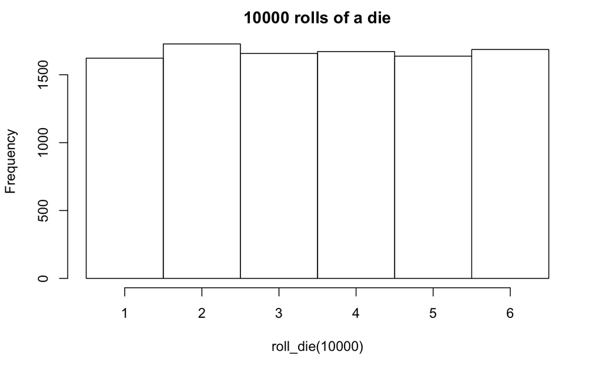

```r
roll_die = function(n) sample(1:6,n,rep=T)
hist(roll_die(10000), main=("10000 rolls of a die"), breaks=seq(min-.5,max+.5,1))
```

When it comes to randomness, there are all sorts of reasons why errors, noise and uncertainties accompanies our observations, the intuition here is to separate the noise from the signal.